# HA 4

```r
library(pROC)
```

```r
titanic <- read_delim("C:/Users/julia/Desktop/Wahlpflicht-Data Science/data/titanic.csv",
    ";", escape_double = FALSE, col_types = cols(age = col_double(),
        boat = col_double()), na = "NA",
    trim_ws = TRUE)
```

[output not shown]

**Bitte erstellen Sie ein Notebook mit weiteren Features**

- Würde ein Notebook mit siblings und Klasse erstellen und auch die surviver mit aufnehmen.

*Es wäre interessant zu untersuchen, welche Geschwister aus welcher Klasse sich retten konnten.

P.S.: ich habe das mit omit.na nicht gemacht, weil ich gesehen hatte, dass für meine Gegenstände der Untersuchung es nicht nötig gewesen wäre. Die Klasse, Geschwister und Überlebende-Kategorien sind ohne na´s im Datensatz vorhanden.

```r
inTrain <- createDataPartition(
  y = analyse$survived,
  p = .8,
  list = FALSE)
```

[output not shown]

```r
model.svm <- train(survived~., data=training, trControl=train_control, method="svmLinear")
model.svm <- train(survived~., data=training, trControl=train_control, method="svmLinear")
summary(model.svm)
```

```
Length  Class   Mode
     1   ksvm     S4
```

```r
summary(model.svm)
```

```
Length  Class   Mode
     1   ksvm     S4
```

```r
pred <- predict(model.svm, testing[,-1], probability = FALSE)
```

[output not shown]

[output cut: 990 more lines]

| pred | survived | sibsp | pclass |
| --- | --- | --- | --- |
| 1 | 1 | 0 | 1 |
| 1 | 1 | 1 | 1 |
| 1 | 1 | 1 | 1 |
| 1 | 1 | 0 | 1 |
| 1 | 0 | 0 | 1 |
| 1 | 1 | 0 | 1 |
| 1 | 0 | 0 | 1 |
| 1 | 1 | 0 | 1 |
| 1 | 1 | 0 | 1 |
| 1 | 0 | 0 | 1 |

[output cut: 251 more lines]

```r
table(test.results$pred, testing$survived)
```

```
      0   1
  1 136  65
  2  25  35
```

- Auf der Graphik ist zu sehen, dass der AUC-Wert 0.65 ist, also kann gesagt werden, dass das System fast zufällig entschieden hat/entscheiden wird wer stirbt und wer überlebt, was nicht so weit von der Realität ist.

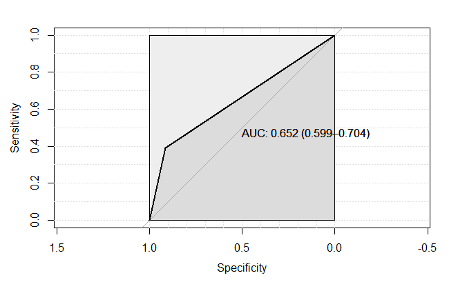

```r
pROC_obj <- roc(test.results$survived, test.results$pred,
            smoothed = TRUE,
            ci=TRUE, ci.alpha=0.9, stratified=FALSE,
            plot=TRUE, auc.polygon=TRUE, max.auc.polygon=TRUE, grid=TRUE,
            print.auc=TRUE, show.thres=TRUE)
```

```r
saveRDS(model.svm, "./titanic2.svm.rds")
```

- Nun ist es Zeit für Naive Bayes

Innerhalb dieser Untersuchung wäre interessant zu sehen welche Wahrscheinlichkeit bestünde, wenn die Menschen mit der 1.Klasse etc. gefahren haben.

```r
bayes
```

```
Naive Bayes Classifier for Discrete Predictors

Call:
naiveBayes.default(x = X, y = Y, laplace = laplace)

A-priori probabilities:
Y
        0         1
0.6168582 0.3831418

Conditional probabilities:
   sibsp
Y        [,1]      [,2]
  0 0.5962733 1.2960463
  1 0.4700000 0.7028801

   pclass
Y           1         2         3
  0 0.1552795 0.2111801 0.6335404
  1 0.3500000 0.2800000 0.3700000
```

```r
table(wahr, training2$survived)
```

```
wahr   0   1
   0 105  40
   1  56  60
```

| wahr | survived | sibsp | pclass |
| --- | --- | --- | --- |
| 1 | 1 | 0 | 1 |
| 1 | 1 | 1 | 1 |
| 1 | 1 | 1 | 1 |
| 1 | 1 | 0 | 1 |
| 1 | 0 | 0 | 1 |
| 1 | 1 | 0 | 1 |
| 1 | 0 | 0 | 1 |
| 1 | 1 | 0 | 1 |
| 1 | 1 | 0 | 1 |
| 1 | 0 | 0 | 1 |

[output cut: 251 more lines]

- Aus diesem Diagramm ist zu erkennen, dass das System doch fast zufällig entscheidet/entschieden hat wer überlebt und wer nicht.

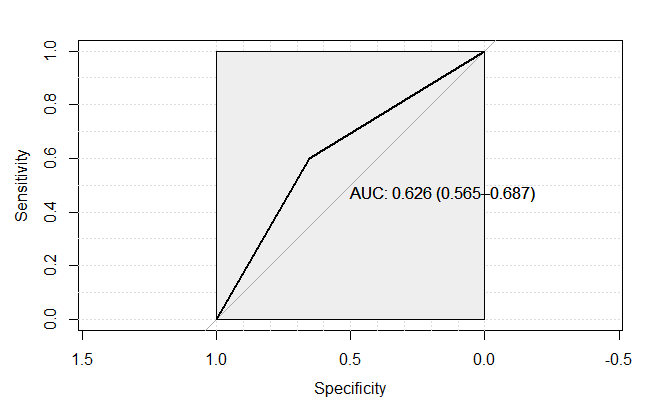

```r
pROC_obj <- roc(as.numeric(as.factor(erg$survived)), erg$num, smoothed=T, ci=T, ci.alpha=0.7, stratified=F, plot=T, aus.polygon=T, max.auc.polygon=T, grid=T, print.auc=T, show.thres=T)
```